# Airlines Fatalities

## Model5 diagnostics

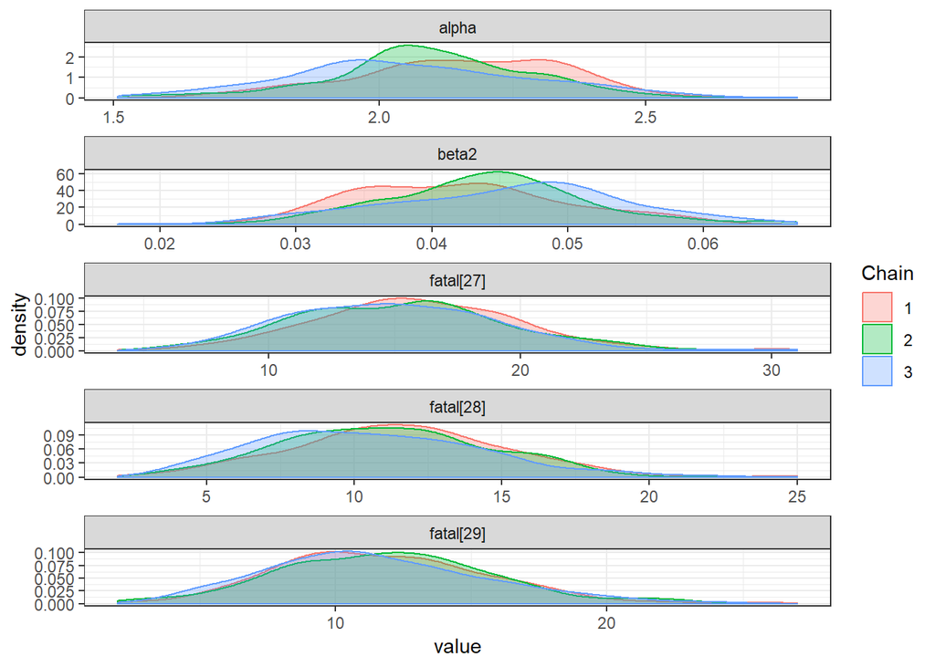

```r
result5 = ggs(a5.res)
ggs_density(result5)
```

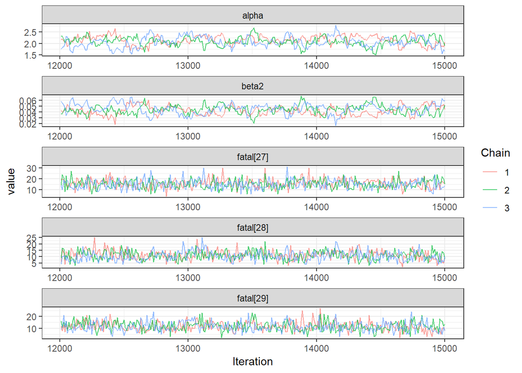

```r
ggs_traceplot(result5)
```

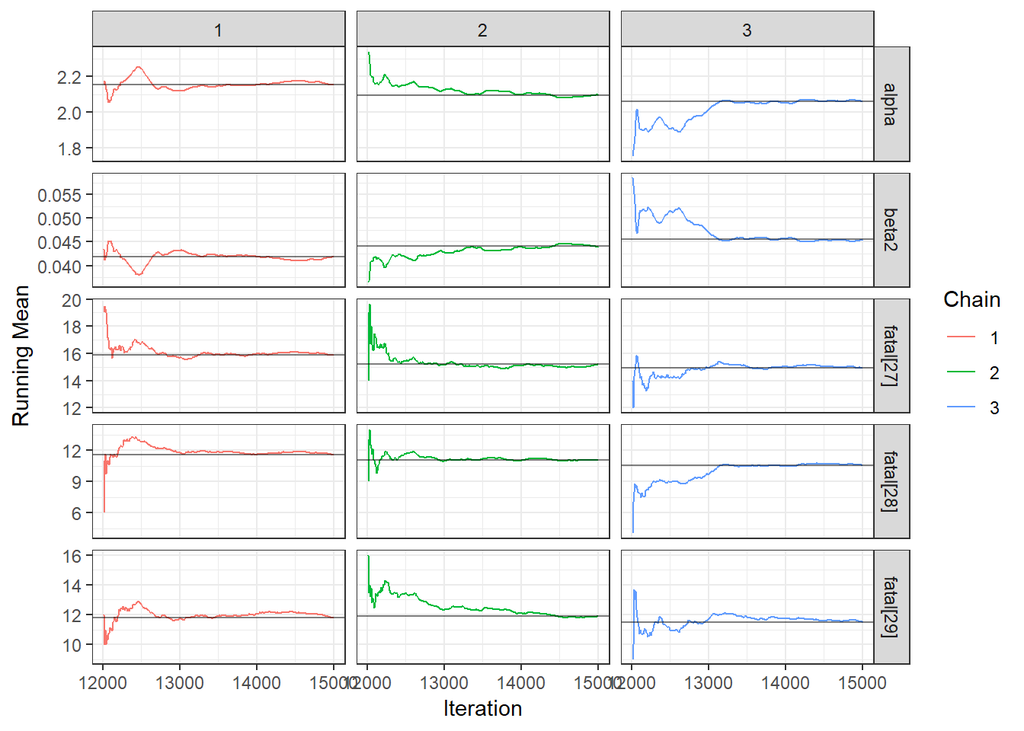

```r
ggs_running(result5)
```

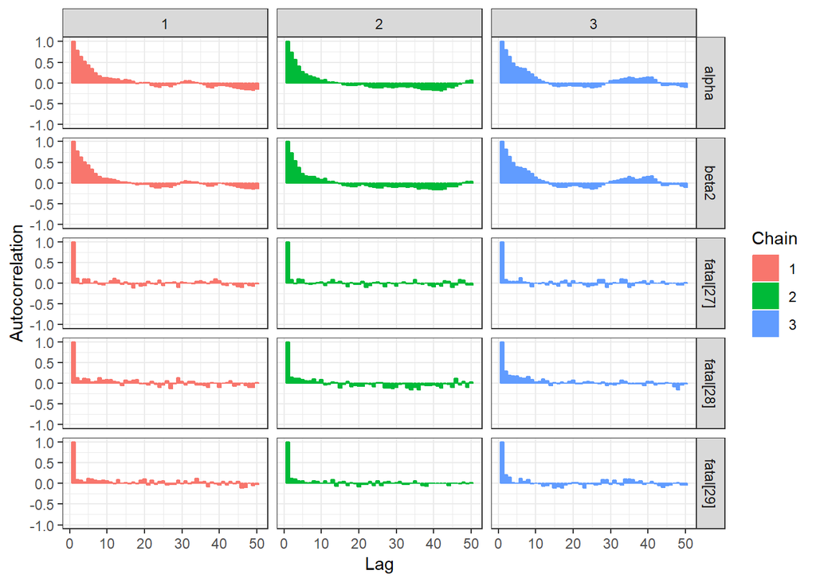

```r
ggs_autocorrelation(result5)
```

## Predicting values in model 5

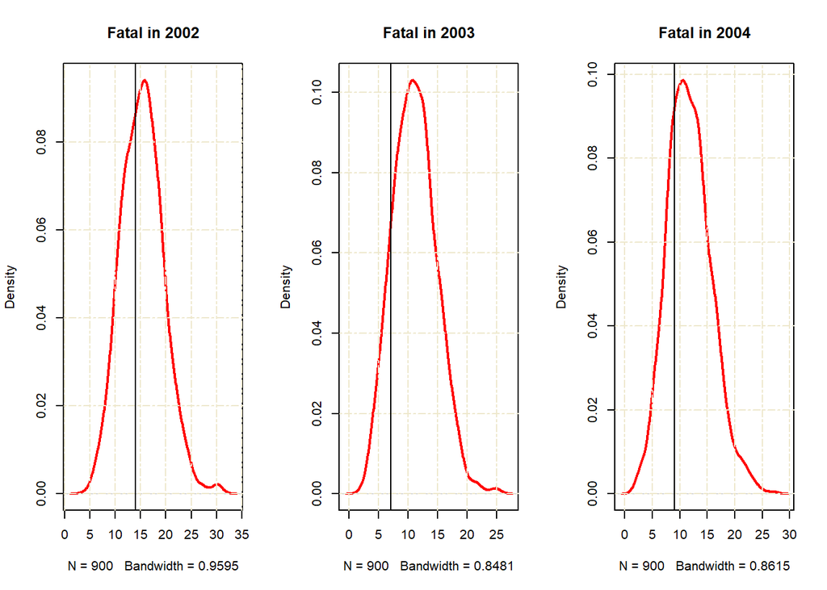

```r
par(mfrow=c(1,3))
a5.m <- as.matrix(a5.res)
plot(density(a5.m[,"fatal[27]"]),main="Fatal in 2002", col="red", lwd=2)
grid (NULL,NULL, lty = 6, col = "cornsilk2")
abline( v=14,col="black")
a5.m <- as.matrix(a5.res)
plot(density(a5.m[,"fatal[28]"]),main="Fatal in 2003", col="red", lwd=2)
grid (NULL,NULL, lty = 6, col = "cornsilk2")
abline( v=7,col="black")
a5.m <- as.matrix(a5.res)
plot(density(a5.m[,"fatal[29]"]),main="Fatal in 2004", col="red", lwd=2)
grid (NULL,NULL, lty = 6, col = "cornsilk2")
abline( v=9,col="black")
```

# Table of true values

```
  Year      Fatal accidents   Passenger miles    Accident rate


  2002      14                19.775             0.7080
  2003      7                 23.300             0.3004
  2004      9                 20.300             0.4433
```

## Model comparison throughout DIC index

A good way to select the model that fits best our data, is using the DIC measure. The DIC (deviance information criterion) is a Bayesian criterion for model comparison, defined as:
$$DIC = D(\bar{\theta}) + 2_{p_D}$$
Where: $D(\theta) = -2logL(\theta)$, $p_D = \bar D - D(\bar \theta)$, is the effective number of paramenters of the model, the larger $p_D$ the easier the model fits on the data. $\bar D = E[D(\theta)]$, its the mean deviance. is a measure of how well the model fits the data, the larger the worse the fit. $D(\bar \theta) = D[E(\theta)]$

the basic idea is that the models with smaller DIC should be preferred. Models are penalized both by the value of $\bar D$, which favors a good fit, but also by the effective number of parameters $p_D$. Since $\bar D$ will decrease as the number of parameters in a model increases, the $p_{D}$ term compensates for this effect by favoring models with a smaller number of parameters.

```r
#Model Comparison
DICmodel1 = dic.samples(a1.mod, n.iter=10000, thin=10, type="pD")
DICmodel3 = dic.samples(a3.mod, n.iter=10000, thin =10, type="pD")
DICmodel4 = dic.samples(a4.mod, n.iter=10000, thin=10, type="pD")
DICmodel5 = dic.samples(a5.mod, n.iter=10000, thin =10, type="pD")


DICmodel1
```

```
## Mean deviance:  156.2
## penalty 1.024
## Penalized deviance: 157.3
```

```r
DICmodel3
```

```
## Mean deviance:  133.9
## penalty 3.011
## Penalized deviance: 136.9
```

```r
DICmodel4
```

```
## Mean deviance:  132.9
## penalty 2.055
## Penalized deviance: 134.9
```

```r
DICmodel5
```

```
## Mean deviance:  154.7
## penalty 2.178
## Penalized deviance: 156.9
```